# Assignment 9: Graduate School Admissions

Kate Fox

2026-03-24

### Introduction

In this assignment, I analyzed predictors of graduate school admissions using GPA, GRE, and undergraduate school ranking.

### Data Loading & Cleaning

```r
library(tidyverse)
admissions <- read_csv("GradSchool_Admissions.csv")
glimpse(admissions)
```

```
## Rows: 400
## Columns: 4
## $ admit <dbl> 0, 1, 1, 1, 0, 1, 1, 0, 1, 0, 0, 0, 1, 0, 1, 0, 0, 0, 0, 1, 0, 1…
## $ gre   <dbl> 380, 660, 800, 640, 520, 760, 560, 400, 540, 700, 800, 440, 760,…
## $ gpa   <dbl> 3.61, 3.67, 4.00, 3.19, 2.93, 3.00, 2.98, 3.08, 3.39, 3.92, 4.00…
## $ rank  <dbl> 3, 3, 1, 4, 4, 2, 1, 2, 3, 2, 4, 1, 1, 2, 1, 3, 4, 3, 2, 1, 3, 2…
```

```r
summary(admissions)
```

```
##      admit             gre             gpa             rank
##  Min.   :0.0000   Min.   :220.0   Min.   :2.260   Min.   :1.000
##  1st Qu.:0.0000   1st Qu.:520.0   1st Qu.:3.130   1st Qu.:2.000
##  Median :0.0000   Median :580.0   Median :3.395   Median :2.000
##  Mean   :0.3175   Mean   :587.7   Mean   :3.390   Mean   :2.485
##  3rd Qu.:1.0000   3rd Qu.:660.0   3rd Qu.:3.670   3rd Qu.:3.000
##  Max.   :1.0000   Max.   :800.0   Max.   :4.000   Max.   :4.000
```

```r
admissions <- admissions %>%
  mutate(
    admit = as.factor(admit),
    rank = as.factor(rank)
  )
```

### Exploratory Data Analysis

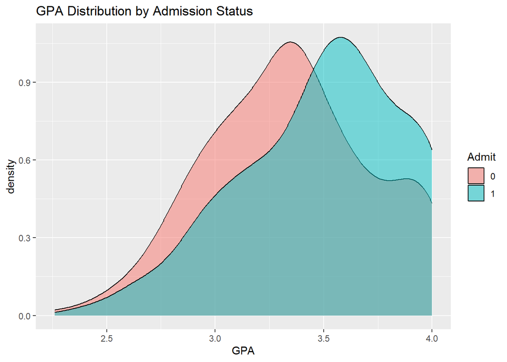

```r
# GPA vs Admission
ggplot(admissions, aes(x = gpa, fill = admit)) +
  geom_density(alpha = 0.5) +
  labs(title = "GPA Distribution by Admission Status", x = "GPA", fill = "Admit")
```

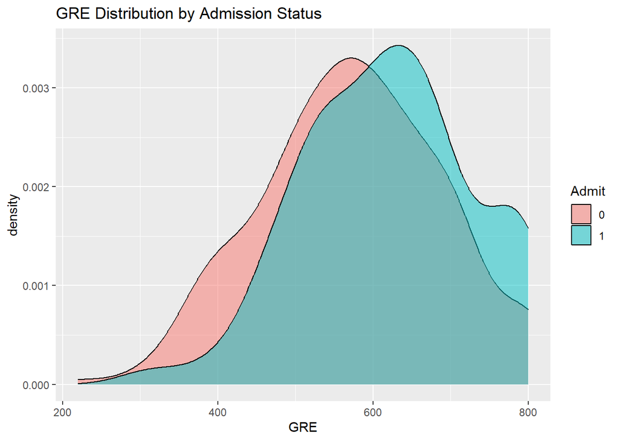

```r
# GRE vs Admission
ggplot(admissions, aes(x = gre, fill = admit)) +
  geom_density(alpha = 0.5) +
  labs(title = "GRE Distribution by Admission Status", x = "GRE", fill = "Admit")
```

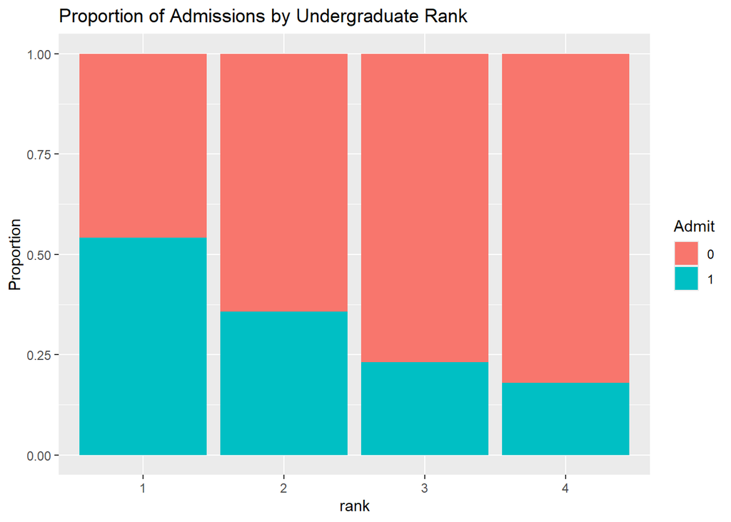

```r
# Rank vs Admission
ggplot(admissions, aes(x = rank, fill = admit)) +
  geom_bar(position = "fill") +
  labs(title = "Proportion of Admissions by Undergraduate Rank", y = "Proportion", fill = "Admit")
```

The first two graphs indicate that higher GPA and GRE increase admission probability. A higher rank (1) has higher proportion of admitted students, so rank does matter.

# Model 1

```r
# Model 1: GPA only
mod1 <- glm(admit ~ gpa, data = admissions, family = binomial)
summary(mod1)
```

```
##
## Call:
## glm(formula = admit ~ gpa, family = binomial, data = admissions)
##
## Coefficients:
##             Estimate Std. Error z value Pr(>|z|)
## (Intercept)  -4.3576     1.0353  -4.209 2.57e-05 ***
## gpa           1.0511     0.2989   3.517 0.000437 ***
## ---
## Signif. codes:  0 '***' 0.001 '**' 0.01 '*' 0.05 '.' 0.1 ' ' 1
##
## (Dispersion parameter for binomial family taken to be 1)
##
##     Null deviance: 499.98  on 399  degrees of freedom
## Residual deviance: 486.97  on 398  degrees of freedom
## AIC: 490.97
##
## Number of Fisher Scoring iterations: 4
```

```r
# Model 2: GPA + GRE
mod2 <- glm(admit ~ gpa + gre, data = admissions, family = binomial)
summary(mod2)
```

```
##
## Call:
## glm(formula = admit ~ gpa + gre, family = binomial, data = admissions)
##
## Coefficients:
##              Estimate Std. Error z value Pr(>|z|)
## (Intercept) -4.949378   1.075093  -4.604 4.15e-06 ***
## gpa          0.754687   0.319586   2.361   0.0182 *
## gre          0.002691   0.001057   2.544   0.0109 *
## ---
## Signif. codes:  0 '***' 0.001 '**' 0.01 '*' 0.05 '.' 0.1 ' ' 1
##
## (Dispersion parameter for binomial family taken to be 1)
##
##     Null deviance: 499.98  on 399  degrees of freedom
## Residual deviance: 480.34  on 397  degrees of freedom
## AIC: 486.34
##
## Number of Fisher Scoring iterations: 4
```

```r
# Model 3: GPA + GRE + Rank
mod3 <- glm(admit ~ gpa + gre + rank, data = admissions, family = binomial)
summary(mod3)
```

```
##
## Call:
## glm(formula = admit ~ gpa + gre + rank, family = binomial, data = admissions)
##
## Coefficients:
##              Estimate Std. Error z value Pr(>|z|)
## (Intercept) -3.989979   1.139951  -3.500 0.000465 ***
## gpa          0.804038   0.331819   2.423 0.015388 *
## gre          0.002264   0.001094   2.070 0.038465 *
## rank2       -0.675443   0.316490  -2.134 0.032829 *
## rank3       -1.340204   0.345306  -3.881 0.000104 ***
## rank4       -1.551464   0.417832  -3.713 0.000205 ***
## ---
## Signif. codes:  0 '***' 0.001 '**' 0.01 '*' 0.05 '.' 0.1 ' ' 1
##
## (Dispersion parameter for binomial family taken to be 1)
##
##     Null deviance: 499.98  on 399  degrees of freedom
## Residual deviance: 458.52  on 394  degrees of freedom
## AIC: 470.52
##
## Number of Fisher Scoring iterations: 4
```

```r
# Compare models
AIC(mod1, mod2, mod3)
```

```
##      df      AIC
## mod1  2 490.9676
## mod2  3 486.3440
## mod3  6 470.5175
```

GPA is significant on it’s own. Adding GRE improves the model slightly. Rank is significant, so model 3 is the best when comparing with AIC.

### Model Evaluation & Predicted Probabilities

# Add Predicted Probabilities from Model 3

```r
admissions <- admissions %>%
  mutate(pred_prob = predict(mod3, type = "response"))
admissions
```

```
## # A tibble: 400 × 5
##    admit   gre   gpa rank  pred_prob
##    <fct> <dbl> <dbl> <fct>     <dbl>
##  1 0       380  3.61 3         0.173
##  2 1       660  3.67 3         0.292
##  3 1       800  4    1         0.738
##  4 1       640  3.19 4         0.178
##  5 0       520  2.93 4         0.118
##  6 1       760  3    2         0.370
##  7 1       560  2.98 1         0.419
##  8 0       400  3.08 2         0.217
##  9 1       540  3.39 3         0.201
## 10 0       700  3.92 2         0.518
## # ℹ 390 more rows
```

# Plot Predicted Probabilities by Actual Admission

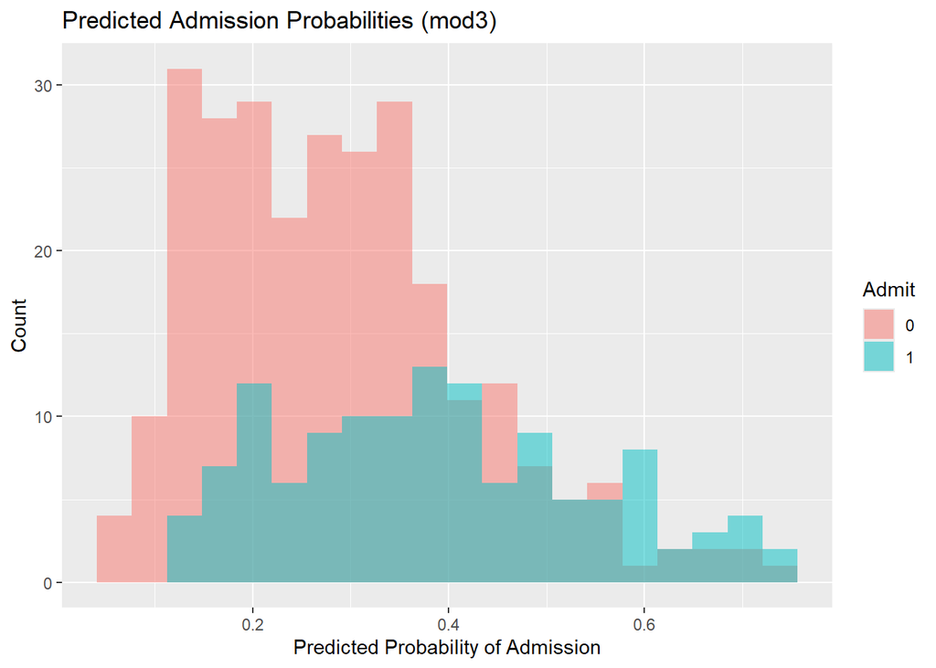

```r
ggplot(admissions, aes(x = pred_prob, fill = admit)) +
  geom_histogram(position = "identity", alpha = 0.5, bins = 20) +
  labs(title = "Predicted Admission Probabilities (mod3)",
       x = "Predicted Probability of Admission",
       y = "Count",
       fill = "Admit")
```

The histogram shows that students who were admitted tend to have higher predicted probabilities, which suggests that our model is reasonable in comparing admitted and non-admitted students.

### Odds Ratios for Interpretation

```r
# Odds Ratios
odds_ratios <- exp(coef(mod3))
odds_ratios
```

```
## (Intercept)         gpa         gre       rank2       rank3       rank4
##   0.0185001   2.2345448   1.0022670   0.5089310   0.2617923   0.2119375
```

```r
# Display as a Table
data.frame(
  Predictor = names(odds_ratios),
  Odds_Ratio = odds_ratios
)
```

```
##               Predictor Odds_Ratio
## (Intercept) (Intercept)  0.0185001
## gpa                 gpa  2.2345448
## gre                 gre  1.0022670
## rank2             rank2  0.5089310
## rank3             rank3  0.2617923
## rank4             rank4  0.2119375
```

Odds ratios show how each predictor affects the odds of admission. A GPA odds ratio of >1 means higher GPA increases the odds of being admitted.

#Visualizing Effects of Rank

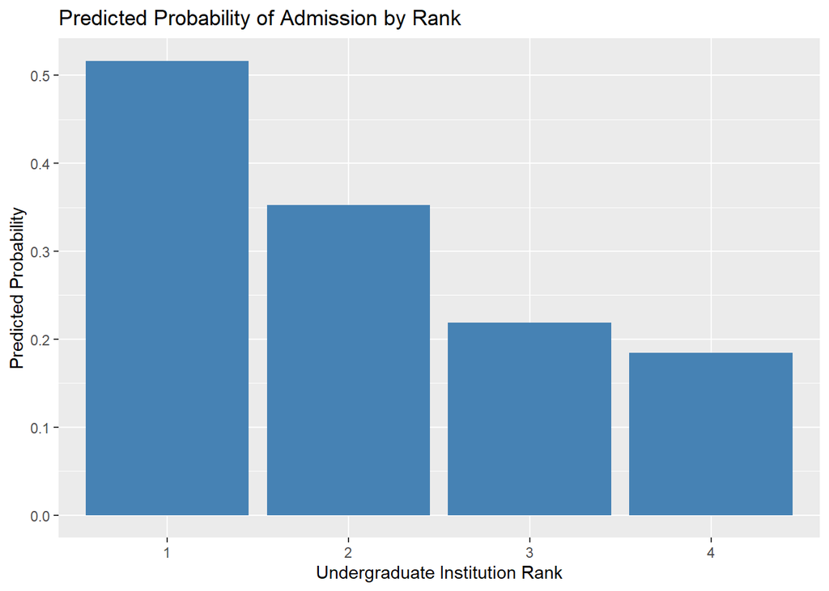

```r
### Admission Probability by Rank ###
# Predict admission probability for each rank at average GRE and GPA
avg_gre <- mean(admissions$gre)
avg_gpa <- mean(admissions$gpa)

rank_pred <- data.frame(
  gre = avg_gre,
  gpa = avg_gpa,
  rank = factor(1:4, levels = levels(admissions$rank))
)
rank_pred$pred_prob <- predict(mod3, newdata = rank_pred, type = "response")

ggplot(rank_pred, aes(x = rank, y = pred_prob)) +
  geom_col(fill = "steelblue") +
  labs(title = "Predicted Probability of Admission by Rank",
       x = "Undergraduate Institution Rank",
       y = "Predicted Probability")
```

Holding GRE and GPA constant, top-tier schools (Rank 1) have higher predicted probabilities of admission compared to lower-ranked schools, confirming that undergraduate rank matters.

### Conclusion

GPA was a strong predictor of graduate school admission, with higher GPA values associated with increased probability of acceptance. GRE scores showed a weaker effect, suggesting they are less important than GPA.

Undergraduate rank significantly affects admission, with students from top-tier schools having a higher admission rate. The regression model including GPA, GRE, and rank (mod3) fits the data best because it has the lowest AIC.

Predicted probabilities and odds ratios provide interpretable insights for understanding admission likelihood.